# Imdb

Jan Alexandersson

February 10, 2018

# Introduktion

De flesta av oss känner nog igen sig i att efter en lång vecka slå sig ner framför tv:n på fredagkvällen med chipsen redo och mysbrallorna på. Middagen är nere i magen och disken är diskad och nu finns det bara ett problem. Vilken film ska man välja?

Detta dilemma är ofta helt avgörande för hur kvällen kommer bli. Ett vanligt utfall är att det blir vilda diskussioner om vilken film det ska bli och tillslut är alla på så dåligt humör att ingen längre vill se på film. Ett annat utfall kan vara att man tar till internet och söker efter vilka filmer som är populära. Det senare blev i alla fall utfallet för mig, vilket förde mig till [Imdb:s lista över de mest populära filmerna släppna $2017$](http://www.imdb.com/search/title?year=2017&title_type=feature&). Den fick mig att fundera på om populära filmer nödvändigdvis får bättre betyg. En film med dåligt betyg kan fortfarande vara en film anses vara populär. Jag bestämde mig då för att vidare undersöka informationen som finns i listan.

# Data

De variablerna jag har skrapat är:

- Titel
- Popularitetsrank i listan
- Genre
- Imdb-betyg
- Inkomst
- Speltid
- Regissör
- Metascore (ett viktat medelvärde att betyg från filmkritiker)
- Skådespelare

# Genreanalys

```r
#den här funktionen sköter inläsningen av websidan
imdb_func <- function(url){

  webpage <- read_html(url)
  #nedan använder jag en extention i webbläsaren, CSS selector för att hitta nodes

  #popularity_rank
  popularity_rank <- html_text(html_nodes(webpage, '.text-primary'))

  #title
  title <- html_text(html_nodes(webpage, '.lister-item-header a'))

  #genre
  genre <-  html_text(html_nodes(webpage, '.genre'))

  #imdb_score
  #här tar jag med både rank och imdb_score
  #rank slutar alltid med en punkt och imdb_score slutar alltid med siffra
  #jag byter ut alla element i listan som slutar på punkt mot "x"
  #detta gör jag för att jag ska kunna hitta saknade värden
  #dvs har jag nu två "x" i rad så saknas det ett imdb_score emellan
  #detta tas hand om senare
  imdb_score <- html_text(html_nodes(webpage, '.ratings-imdb-rating strong , .text-primary'))
  imdb_score <- gsub(".*\\.$","x", imdb_score)

  #gross
  #samma princip här för saknade värden som i imdb_score
  gross <-  html_text(html_nodes(webpage, ".ghost~ .text-muted+ span , .text-primary"))
  gross <- gsub(".*\\.$","x", gross)

  #runtime
  #lägger till "x" för att hantera saknade värden på hemsidan
  runtime <- html_text(html_nodes(webpage, '.text-primary , .text-muted .runtime'))
  runtime <- gsub(".*\\.","x", runtime)


  #metascore
  #lägger till "x" för att hantera saknade värden på hemsidan
  metascore <- html_text(html_nodes(webpage, '.unfavorable , .mixed , .favorable , .text-primary'))
  metascore <- gsub(".*\\.","x", metascore)


  #director
  director <-html_text( html_nodes(webpage, '.text-muted+ p a:nth-child(1)'))

  #actors
  #får ut stränar med 4 skådespelare som jag sedan rensar så att endast namnen är kommaseparerade
  #splitar sedan alla strängar vid komma
  actor <- html_text(html_nodes(webpage, '.text-muted~ .text-muted+ p , .ratings-bar~ .text-muted+ p'))
  actor <- gsub(".*Stars:", "", actor)
  actor <- gsub("\n", "", actor)
  actor <- gsub("  ", "", actor)
  actor <- strsplit(actor, ", ")

  #denna funktion tar sedan ut den nte skådespelaren ur varje film
  #det vill säga att den plockar ut de skådespelare på position number, som listas i ordningen på hemsidan
  nthActor <- function(actor, number){
    actorList <- c()
    for(i in 1:length(actor)){
      actorList <-append(actorList, actor[[i]][number])
    }
    return(actorList)
  }
  #använder funktionen och får ut alla skådespelare
  #actor1 innehåller alltså den första skådespelaren för varje film, osv
  actor1 <- nthActor(actor, 1)
  actor2 <- nthActor(actor, 2)
  actor3 <- nthActor(actor, 3)
  actor4 <- nthActor(actor, 4)

  #här kommer funktionen som utnyttjar att "x" är inlagt i några listor
  #den kollar helt enkelt om det finns två stycken "x" i rad och lägger in ett NA emellan dem
  #sedan tas alla "x" bort
  missingValues <- function(attribute){
    missingValuesInAttribute <- c()
    for(i in 1:(length(attribute)-1)){
      if( (attribute[i] == "x") & (attribute[i+1] == "x") ){
        missingValuesInAttribute <- append(i+1, missingValuesInAttribute)
      }
    }

    for (i in missingValuesInAttribute){

      a<-attribute[1:(i-1)]

      b<-attribute[i:length(attribute)]

      attribute <-append(a,list("NA"))

      attribute<-append(attribute,b)

    }
    #specialfall som inte hanteras av ovanstående kod
    #om det är ett saknat värde i slutet så behöver det inte vara två "x" i rad
    #om sista värdet är "x" läggs NA till efter
    if(attribute[length(attribute)] == "x"){
      attribute <-append(attribute, "NA")
    }

    attribute <- unlist(attribute[! (attribute %in% "x") ])
    return(attribute)
  }

  #lägger in saknade värden
  imdb_score <- missingValues(imdb_score)
  gross <- missingValues(gross)
  metascore <- missingValues(metascore)
  runtime <- missingValues(runtime)

  v <- list(title, popularity_rank, genre, imdb_score, gross, runtime, director,metascore,
            actor1, actor2, actor3, actor4)

  return(v)
}
```

```r
#den här funktionen sätter ihop en dataframe från inläsning av flera sidor i imdb-listan
#inte nödvändigt med en funktion här men för tydlighetens skull valde jag att ha det
getPagesMakeDf <- function(webpage_url, pages){
  #assignar tomma vektorer som sedan ska fyllas i med info från de websidan
  title <- c()
  popularity_rank <- c()
  genre <- c()
  imdb_score <- c()
  gross <- c()
  runtime <- c()
  director <- c()
  metascore <- c()
  actor1 <- c()
  actor2 <- c()
  actor3 <- c()
  actor4 <- c()
  ###################################

  #listan på imdb består av flera sidor, så här loopas inläsning av ett valt antal sidor i listan
  #varje sida innehåller 50st filmer
  for(i in 1:pages){
    url <- paste0(webpage_url, "page=" , i)
    #temporär lista som ska läggas på på de olika variablerna vi assignade tidigare
    temp <- imdb_func(url)

    title <- c(title,temp[[1]])
    popularity_rank <- c(popularity_rank, temp[[2]])
    genre <- c(genre, temp[[3]])
    imdb_score <- c(imdb_score, temp[[4]])
    gross <- c(gross,temp[[5]])
    runtime <- c(runtime, temp[[6]] )
    director <- c(director, temp[[7]] )
    metascore <- c(metascore, temp[[8]] )
    actor1 <- c(actor1, temp[[9]] )
    actor2 <- c(actor2, temp[[10]])
    actor3 <- c(actor3, temp[[11]])
    actor4 <- c(actor4, temp[[12]])
  }

  ##########################################################

  #sätter ihop allt och skapar en dataframe
  imdb_df <- data.frame(popularity_rank, genre, imdb_score, gross, runtime, director,metascore,
                actor1,actor2, actor3, actor4, stringsAsFactors=FALSE)


  #rensar dataframen från oönskat "skräp" så som tecken och liknande så att
  #värden kan göras om till numeriska
  imdb_df <- imdb_df %>%
    mutate(popularity_rank = gsub("\\." , "" , popularity_rank)) %>%
    mutate(popularity_rank = as.numeric(popularity_rank)) %>%
    mutate(genre = gsub("\n" , "", genre)) %>%
    mutate(genre = gsub(" " , "", genre)) %>%
    mutate(imdb_score = as.numeric(imdb_score)) %>%
    mutate(gross = gsub("\\$|M", "", gross)) %>%
    mutate(gross = as.numeric(gross)) %>%
    mutate(runtime = gsub(" min", "" , runtime)) %>%
    mutate(runtime = as.numeric(runtime)) %>%
    mutate(metascore = gsub(" ","", metascore)) %>%
    mutate(metascore = as.numeric(metascore))

  #Det fanns två filmer med samma namn, film 1 och film 2, fast det stod inte i titeln
  #unique= TRUE löser detta så att alla radnamn blir unika
  rownames(imdb_df) <- gsub("\\."," ", make.names(title, unique = TRUE))

  return(imdb_df)
}

#"http://www.imdb.com/search/title?year=2017&title_type=feature&"
#nu finns dataframen tillgänglig globalt i workspace
imdb_df <- getPagesMakeDf("http://www.imdb.com/search/title?year=2017&title_type=feature&", 10)
genre_func <- function(dataframe){
  #för tar vi reda på vilka genrer som finns representerade i datasetet, dvs alla unika genrer
  genres <- dataframe$genre %>% strsplit(",") %>% unlist() %>% unique()

  genre_df <- data.frame(select(dataframe, genre) )
  #skapar nollfyllda kolumner med de olika genrerna som variabelnamn
  for(i in genres){
    genre_df[,i] <- rep(0, nrow(genre_df))
  }

  #för varje film och genre så byts 0 mot 1 där en "matchning" i genre-kolumnen i den
  #usprungliga dataframen
  for(j in 1:nrow(genre_df)){

    for(i in genres){

      #grepl är liknande str_detect
      if(grepl(i , genre_df$genre[j])){
        genre_df[j,i]<- 1
      }
    }
  }
  #Sci-Fi skapade problem med bindestreck så detta tas bort
  genre_df <- genre_df%>% select(-genre)
  names(genre_df) <- gsub("-", "", names(genre_df) )

  return(genre_df)
}

#en dataframe med titel som radnamn och som innehåller
#den glesa matrisen med de olika genrerna som kolumnnamn
genre_df <- genre_func(imdb_df)
#lägger ihop så vi har all info i en dataframe
#spelar ingen roll vilken join som används här, har alltid samma antal rader med samma namn
imdb_df_genres_spread <- inner_join(rownames_to_column(imdb_df), rownames_to_column(genre_df), by = "rowname") %>% select(-rowname, -genre)
#nu finns en dataframe med all den gamla infon och den glesa matrisen med
#nollor och ettor tillsammans som en dataframe tillgänglig

#lägger till radnamnen som tappas
rownames(imdb_df_genres_spread) <- rownames(imdb_df)
```

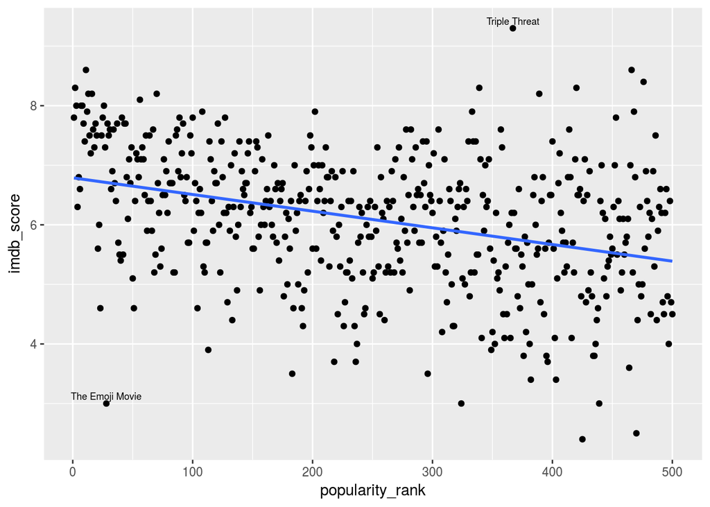

```r
#välj ut den film med högst imdb_score
highestImdbScore <- imdb_df %>%
  rownames_to_column('title') %>%
  slice(which.max(imdb_score))

#väljer filmer med lågt imdb_score men hög popularitet
lowImdbHighPop <- imdb_df %>%
  rownames_to_column('title') %>%
  filter(imdb_score <= 4.0) %>%
  filter(popularity_rank <= 100)

#använder de filmer vi valde ut ovan för att visa deras titel i ploten för de är mest intressanta
imdb_df %>%
  ggplot(aes(x = popularity_rank , y = imdb_score)) +
  geom_point() +
  geom_smooth(method="lm", se = FALSE) +
  geom_text(data = rbind(highestImdbScore ,lowImdbHighPop), aes(x=popularity_rank, y= imdb_score, label = title),
            size = 2.4, vjust = -0.5)
```

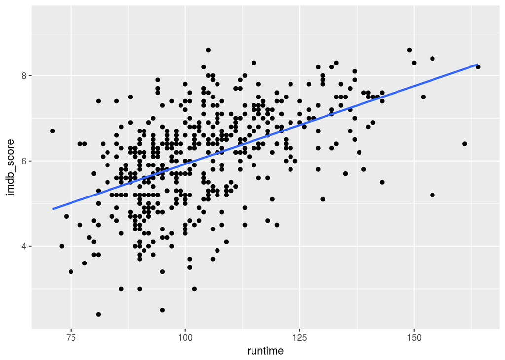

```r
##########################################################
imdb_df %>%
  ggplot(aes(x = runtime , y = imdb_score)) +
  geom_point() +
  geom_smooth(method="lm", se = FALSE)
```

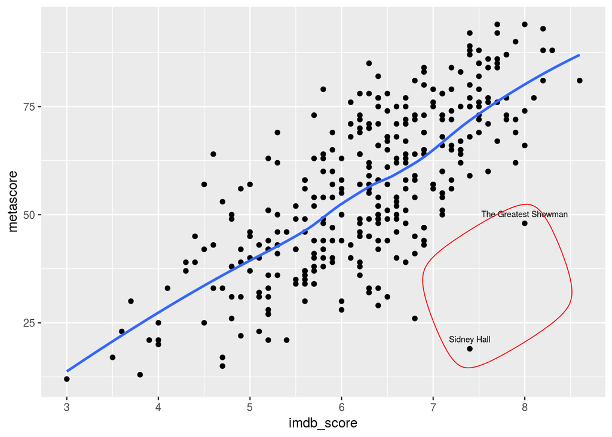

```r
#######################################################
#film som de olika betygstyperna är oense om
#ringar in ett områdde där och plotar text för ett oense område
biggestDiffScore <-imdb_df  %>%
  rownames_to_column('title') %>%
  filter(metascore < 50)  %>%
  filter(imdb_score > 7)
imdb_df %>%
  filter(!is.na(metascore) ) %>%
  ggplot(aes(x = imdb_score , y = metascore)) +
  geom_point() +
  #geom_smooth(method="lm", se = FALSE) +
  geom_smooth(se=FALSE) +
  geom_text(data = biggestDiffScore, aes(x=imdb_score, y= metascore,label = title), size = 2.4, vjust= -1) +
  geom_encircle(aes(x=imdb_score, y=metascore),
                data=biggestDiffScore,
                color="red",
                size=1,
                expand=0.05)
```

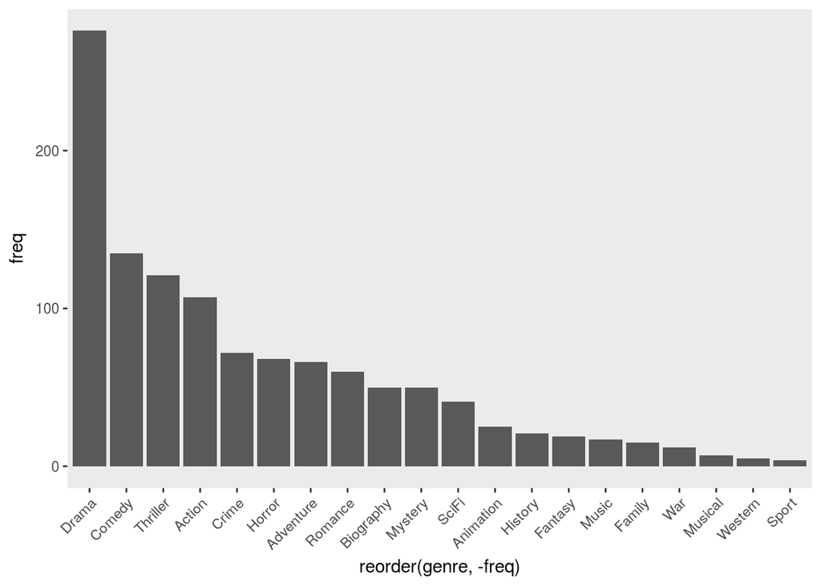

```r
############################################################
#histogram över förekomst av genre
genre_df %>%
  colSums() %>%
  as.data.frame()  %>%
  rownames_to_column("genre") %>%
  `colnames<-`(c("genre", "freq")) %>%
  arrange(-freq) %>%
  ggplot(aes(x=reorder(genre, -freq), y=freq)) +
  geom_bar(stat="identity") +
  theme(axis.text.x = element_text(angle = 45, hjust = 1),
        panel.grid.major = element_blank(), panel.grid.minor = element_blank())
```

```r
#################################################
#räknar förekomster av skådespelare
actors <- as.vector(c(imdb_df$actor1, imdb_df$actor2, imdb_df$actor3, imdb_df$actor4))
actors <- as.data.frame(table(actors)) %>%
  arrange(desc(Freq)) %>%
  slice(1:20)

t1 = actors[1:(nrow(actors)/2),]
t2 = actors[(nrow(actors)/2+1):nrow(actors),]
kable(list(t1,t2))
```

| actors | Freq |
| --- | --- |
| Antonio Banderas | 5 |
| Maika Monroe | 5 |
| Nicolas Cage | 5 |
| Toni Collette | 5 |
| Woody Harrelson | 5 |
| Dan Stevens | 4 |
| Elle Fanning | 4 |
| Gary Oldman | 4 |
| Glenn Close | 4 |
| Jackie Chan | 4 |

| actors | Freq |
| --- | --- |
| Jon Bernthal | 4 |
| Nicholas Hoult | 4 |
| Octavia Spencer | 4 |
| Abbie Cornish | 3 |
| Alicia Vikander | 3 |
| Bella Thorne | 3 |
| Ben Kingsley | 3 |
| Brie Larson | 3 |
| Brittany Snow | 3 |
| Dave Bautista | 3 |

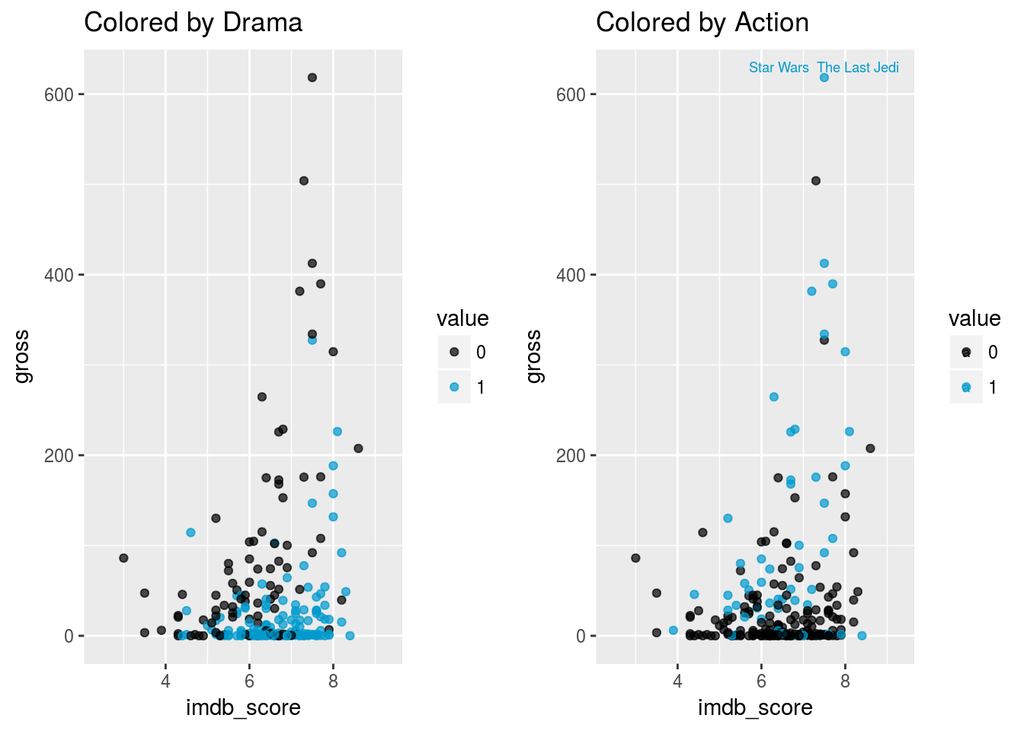

```r
##############################################################
#färglägger alla filmer som är av genren Drama
grossplot1 <- imdb_df_genres_spread %>%
  ggplot(aes(x = imdb_score , y = gross, color = as.factor(Drama))) +
  geom_point(alpha = 0.7) +
  labs(title="Colored by Drama") +
  scale_color_manual(values=c("0"="black", "1"="deepskyblue3")) +
  labs(color = "value")

#väljer den film som dragit in mest pengar och lägger till titel i ploten
highestGrossMovie <- imdb_df_genres_spread %>%
  rownames_to_column('title') %>%
  slice(which.max(gross))
#färglägger alla filmer som är av genren Action
grossplot2 <- imdb_df_genres_spread %>%
  ggplot(aes(x = imdb_score , y = gross, color = as.factor(Action))) +
  geom_point(alpha = 0.7) +
  labs(title="Colored by Action") +
  scale_color_manual(values=c("0"="black", "1"="deepskyblue3")) +
  labs(color = "value") +
  geom_text(data = highestGrossMovie, aes(x=imdb_score, y= gross, label = title), size = 2.4, vjust = -0.5)

#Sätter plottarna bredvid varandra
grid.arrange(grossplot1, grossplot2, ncol=2)
```

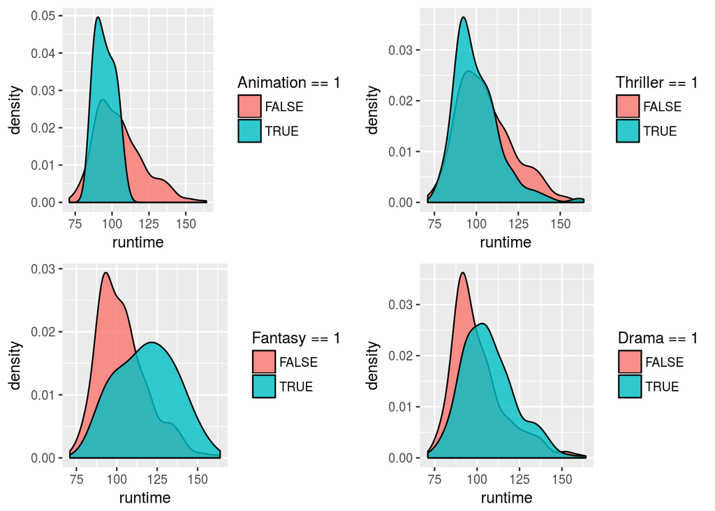

```r
###############################################################################
#RUNTIME
#densityplot över filmernas längd beroende på genre
runtimeplot1 <- imdb_df_genres_spread %>%
  ggplot(aes(x=runtime)) +
  geom_density(aes(fill= Animation==1), alpha = 0.8)

runtimeplot2 <-imdb_df_genres_spread %>%
  ggplot(aes(x=runtime)) +
  geom_density(aes(fill= Thriller==1), alpha = 0.8)

runtimeplot3 <-imdb_df_genres_spread %>%
  ggplot(aes(x=runtime)) +
  geom_density(aes(fill= Fantasy==1), alpha = 0.8)

runtimeplot4 <-imdb_df_genres_spread %>%
  ggplot(aes(x=runtime)) +
  geom_density(aes(fill= Drama==1), alpha = 0.8)


grid.arrange(runtimeplot1, runtimeplot2, runtimeplot3,runtimeplot4, ncol=2, nrow=2)
```

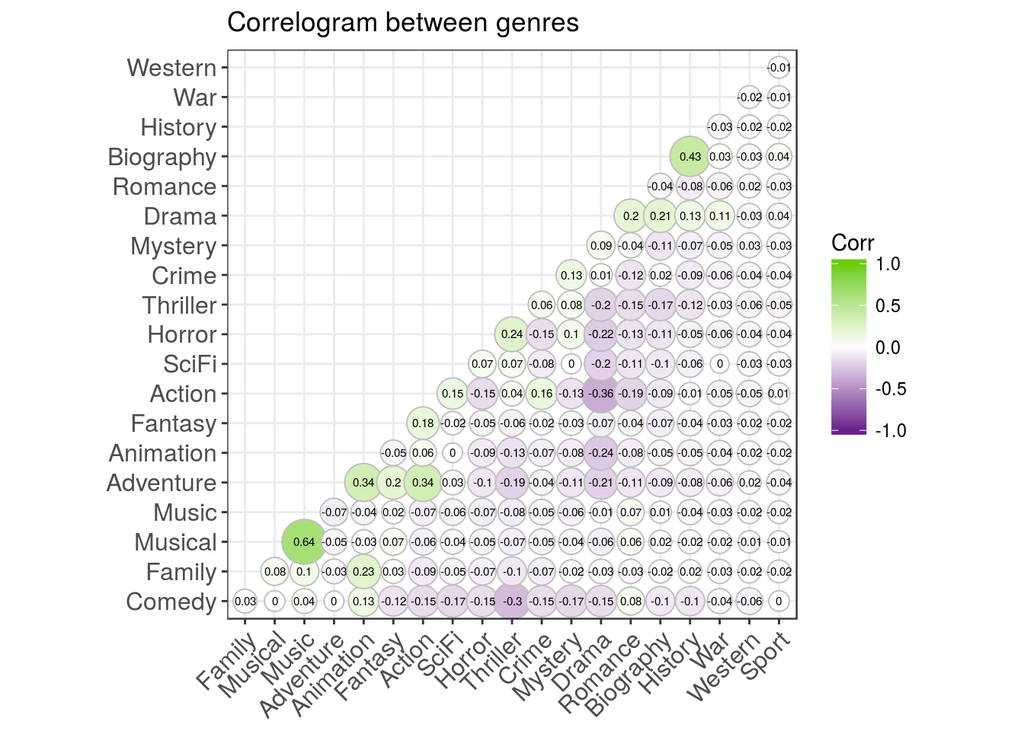

```r
####################################################################
#CORRELOGRAM
#korellogram av genre
corr <- cor(genre_df)
ggcorrplot(corr, hc.order = TRUE,
           type = "lower",
           lab = TRUE,
           lab_size = 2,
           method= "circle",
           colors = c("darkorchid4", "white", "chartreuse3"),
           title="Correlogram between genres",
           ggtheme=theme_bw)
```

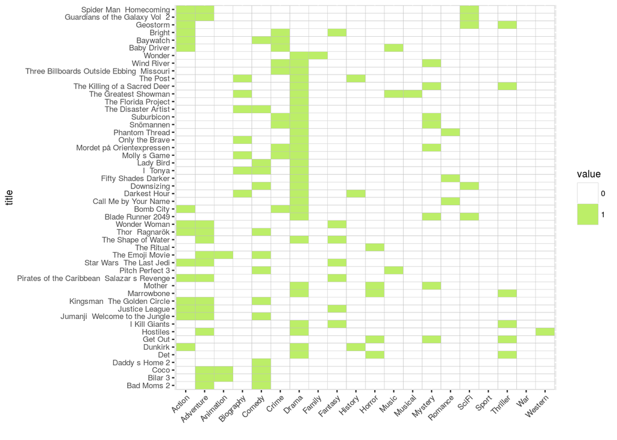

```r
##########################################################

#tar de 50 mest populära filmerna
#lägger till radnamn som av någon anledning försvinner vid slice, filter, mutet, etc..
genre_df_50 <- genre_df %>%
  slice(1:50) %>%
  as.data.frame()
rownames(genre_df_50) = rownames(genre_df)[1:50]

###############################################################

#HEATMAP
cluster_obs <- cutree(hclust(dist(genre_df_50)), k=3)
genre_df_50 %>%
    rownames_to_column("title") %>%
    mutate(title = reorder(title, cluster_obs), cluster = cluster_obs) %>%
    gather(key = key, value = value, colnames(genre_df_50) ) %>%
    mutate(value = as.factor(value)) %>%
    ggplot(aes(x = key, y = title)) +
    geom_tile(aes(fill = value), color = "grey") +
    theme_grey(base_size=8) +
    scale_fill_manual(values=c("0"="white", "1"="darkolivegreen2")) +
    xlab("") +
    theme(axis.text.x = element_text(angle = 45, hjust = 1))
```

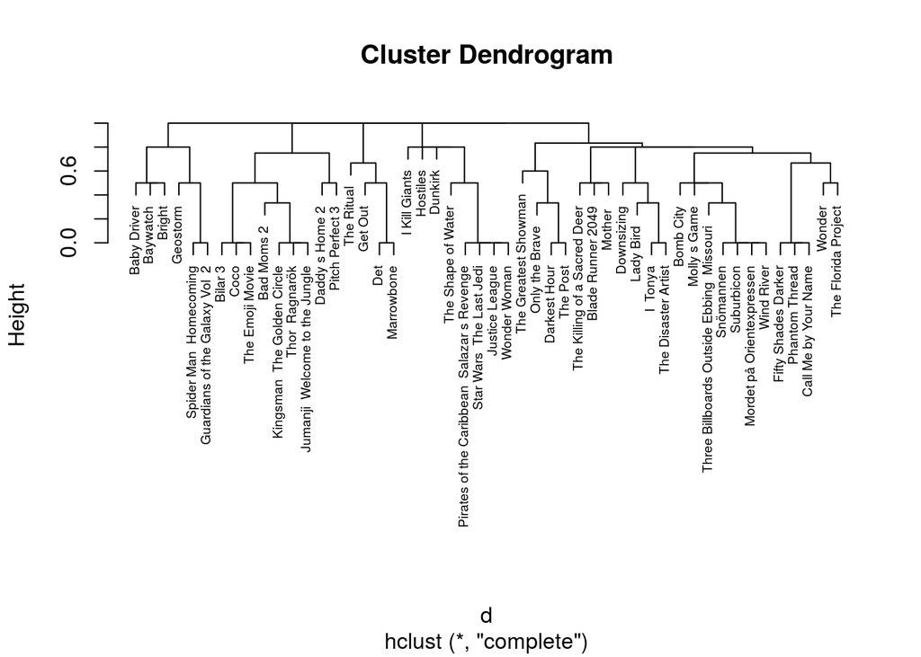

```r
##################################################

#DENDROGRAM
d = dist(genre_df_50 , method = "binary")
hc = hclust(d)
plot(hc,cex = 0.6)
```

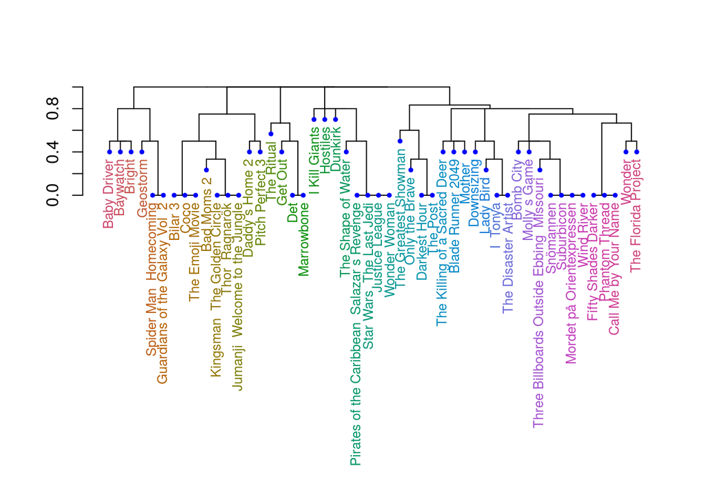

```r
#klustrat dendrogram
#filmer i ett kluster är alltså lika varandra i genre
#gillar man en film i klustret så är chansen stor att man gillar de andra, baserat på genre
dend <- as.dendrogram(hc, hang=0.1) %>%
  color_labels() %>%
  set("leaves_pch", 19) %>%
  set("leaves_cex", 0.5) %>%
  set("leaves_col", "blue") %>%
  set("labels_cex", 0.80)


op <-par(mar =c(15, 4, 4, 2)+ 0.1)
plot(dend, cex = 0.6)
```

```r
par(op)
#####################################################################
```

```r
#
# https://en.wikipedia.org/wiki/The_Shape_of_Water_(film)
#
# titles <- rownames(imdb_df)
#
# titles <- str_replace_all(titles[1:50], "   |  | ", "_")
# titles
#
#
# for(movie in titles){
#     url <- paste0("https://en.wikipedia.org/wiki/", movie, "_(film)")
#   try(
#     webpage <- read_html(url)
#   )
#     hej <- html_text(html_nodes(webpage, '.vevent'))
#     hej <- strsplit(hej, "\n")
#     print(hej)
# }
```

```r
#https://www.the-numbers.com/movies/year/2017
#
# webpage2 <- read_html("https://www.the-numbers.com/movies/year/2017")
# budget <- html_text(html_nodes(webpage2,'.data:nth-child(4) , b a'))
#   #runtime <- html_text(runtime)
#   #budget <- gsub(".*\\.","x", runtime)
#
#
#
# budget <- matrix(budget, ncol = 2, byrow = TRUE )
#
# budget <- data.frame(budget, stringsAsFactors = FALSE) %>%
#   `colnames<-`(c("title", "budget1") )
#
# imdb_df <- rownames_to_column(imdb_df, "title")
# imdb_df %>% left_join(budget, by="title") %>%
#   mutate(budget1 = gsub("\\,","", budget1))  %>%
#   mutate(budget1 = gsub("\\$","", budget1))  %>%
#   mutate(budget1 = gsub(" ","", budget1)) %>%
#   mutate(budget1 = as.numeric(budget1)/1000000)
```

```r
# #skapar en nollfylld kolumn för varje genre och sedan fylls den med ettor om
# #filmen tillhör den genren
# genre_func <- function(dataframe){
#   imdb_df <- dataframe
#   #för tar vi reda på vilka genrer som finns representerade i datasetet, dvs alla unika genrer
#   genres <- imdb_df$genre %>% strsplit(",") %>% unlist() %>% unique()
#
#   #skapar nollfyllda kolumner med de olika genrerna som variabelnamn
#   for(i in genres){
#     imdb_df[,i] <- rep(0, nrow(imdb_df))
#   }
#
#   #för varje film och genre så byts 0 mot 1 där en "matchning" i genre-kolumnen i den
#   #usprungliga dataframen
#   for(j in 1:nrow(imdb_df)){
#
#     for(i in genres){
#
#       if(grepl(i , imdb_df$genre[j])){
#         imdb_df[j,i]<- 1
#       }
#     }
#   }
#   #Sci-Fi skapade problem med bindestreck så detta tas bort
#   imdb_df <- imdb_df%>% select(-genre)
#   names(imdb_df) <- gsub("-", "", names(imdb_df) )
#
#   return(imdb_df)
# }
# #nu finns en dataframe med all den gamla infon och den glesa matrisen med nollor och ettor tillsammans som
# #en dataframe tillgänglig
# imdb_df_genres_spread<-genre_func(imdb_df)
```

```r
# ####################################################################
# #CORRELOGRAM
# #korellogram av genre
# corr <- cor(imdb_df_genres_spread[11:length(imdb_df_genres_spread)] )
# ggcorrplot(corr, hc.order = TRUE,
#            type = "lower",
#            lab = TRUE,
#            lab_size = 2,
#            method= "circle",
#            colors = c("darkorchid4", "white", "chartreuse3"),
#            title="Correlogram between genres",
#            ggtheme=theme_bw)
#
# ##########################################################
#
# #tar bort allt utom titel och genres och gör title till en kolumn
# #radnamn är jobbigt att hantera men förenklar namngivning i plottar
# #av någon anledning tas radnamn bort vid mutate, filer, etc..
# #måste därför lägga till dem igen
# df_title_genre <- imdb_df_genres_spread %>% rownames_to_column("title") %>%
#   slice(1:50) %>%
#   select(-(popularity_rank:actor4)) %>%
#   as.data.frame()
# rownames(df_title_genre ) = df_title_genre$title
#
# ###############################################################
#
# #HEATMAP
# cluster_obs <- cutree(hclust(dist(df_title_genre[,2:length(df_title_genre)])), k=3)
# df_title_genre[,2:length(df_title_genre)] %>%
#     rownames_to_column("title") %>%
#     mutate(title = reorder(title, cluster_obs), cluster = cluster_obs) %>%
#     gather(key = key, value = value, colnames(df_title_genre[,2:length(df_title_genre)]) ) %>%
#     mutate(value = as.factor(value)) %>%
#     ggplot(aes(x = key, y = title)) +
#     geom_tile(aes(fill = value), color = "grey") +
#     theme_grey(base_size=8) +
#     scale_fill_manual(values=c("0"="white", "1"="darkolivegreen2")) +
#     xlab("") +
#     theme(axis.text.x = element_text(angle = 45, hjust = 1))
# ##################################################
#
# #DENDROGRAM
# d = dist(df_title_genre , method = "binary")
# hc = hclust(d)
# plot(hc,cex = 0.6)
#
# #klustrat dendrogram
# #filmer i ett kluster är alltså lika varandra i genre
# #gillar man en film i klustret så är chansen stor att man gillar de andra, baserat på genre
# dend <- as.dendrogram(hc, hang=0.1) %>%
#   color_labels() %>%
#   set("leaves_pch", 19) %>%
#   set("leaves_cex", 0.5) %>%
#   set("leaves_col", "blue") %>%
#   set("labels_cex", 0.80)
#
#
# op <-par(mar =c(15, 4, 4, 2)+ 0.1)
# plot(dend, cex = 0.6)
# par(op)
#
# #####################################################################
```